# prog1_homework04-excIV

Szilágyi Ádám

2017 05 07

```r
tweets <-
  read.table(file = "/Users/Adam/homework-04/data/clinton_trump_tweets.csv", sep = ";", header = T)
```

```r
require(ggplot2)
require(grid)
require(gridExtra)
```

## Leírás:

Sokan állítják, hogy Trump tweetjeit a választási időszakban többen, legalább ketten írták. A következőkben megvizsgálom, hogy az imént behívott tweets dataset alapján igaznak, vagy inkább hamisnak tűnik ez a feltevés.

## Vizsgálat:

```r
levels(as.factor(tweets$source_url))
```

```
## [1] "http://instagram.com"
## [2] "http://twitter.com"
## [3] "http://twitter.com/#!/download/ipad"
## [4] "http://twitter.com/download/android"
## [5] "http://twitter.com/download/iphone"
## [6] "https://about.twitter.com/products/tweetdeck"
## [7] "https://mobile.twitter.com"
## [8] "https://studio.twitter.com"
```

Itt láthatjuk, hogy az 4. és az 5. url az, amelyeknél beazonosítható, hogy milyen eszközről posztolták. Így ezt a kettőt kell kiválasztanom. (Hozzá kell tenni, hogy érdemes lehet az ipad-et is bevenni az elemzésbe, de most ettől eltekintek). A kiválasztott linkek szerint szűrök, az eredményt a forras_vizsg nevű datasetben tárolom el.

```r
forras_vizsg <-
  subset(
    tweets,
    source_url == "http://twitter.com/download/iphone" |
      source_url == "http://twitter.com/download/android" &
      handle == "realDonaldTrump"
  )
```

Majd ezt követően végigfutok az eseteken és egy új ‘op_rendsz’ változóba bele- írom, hogy iPhone-ról, vagy Androidról posztolták. (Attól most tekintsünk el, hogy az iPhone nem operációs rendszer.)

```r
forras_vizsg$op_rendsz <- NA

forras_vizsg$op_rendsz <- NA
for (i in 1:nrow(forras_vizsg)) {
  if (forras_vizsg$source_url[i] == "http://twitter.com/download/iphone") {
    forras_vizsg$op_rendsz[i] <- "Iphone"
  }else{
    forras_vizsg$op_rendsz[i] <- "Android"
  }
}

#Ellenőrzés:
levels(as.factor(forras_vizsg$op_rendsz))
```

```
## [1] "Android" "Iphone"
```

Miután csak a fent látható két típus maradt csak a datasetben, elkezdődhet az adatelemzés. Ezt két módon teszem meg:

- A szövegek szentimentjeit vizsgálom az op_rendsz változó szerint
- A szövegek érzelmi besorolását vizsgálom az op_rendsz változó szerint.

A vizsgálat első lépéseként az ábrákat elemezzük.

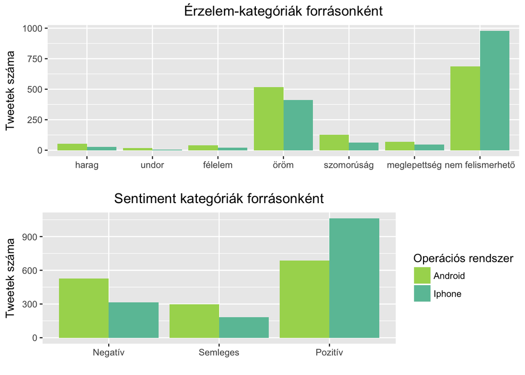

```r
require(ggplot2)

#Sentiment
source_sent <- ggplot(data = forras_vizsg,
                      aes(x = text_sentiment, fill = op_rendsz)) +
  geom_bar(stat = "count",
           position = position_dodge(),
           show.legend = T) +
  theme(plot.title = element_text(hjust = 0.5)) +
  labs(title = "Sentiment kategóriák forrásonként",
       y = "Tweetek száma", x = "") +
  scale_fill_manual(name = "Operációs rendszer",
                    values = c(
  "#a7d65d",
  "#6ac1a5",
  "#fd8977",
  "#fdbf7b",
  "#96d7f8",
  "#fed844",
  "#fbcee5",
  "#e58cc2")) +
  scale_x_discrete(
    breaks = c("negative", "neutral", "positive"),
    labels = c("Negatív", "Semleges", "Pozitív")
  )


#Emotion
source_emo <- ggplot(data = forras_vizsg,
                     aes(x = text_emotion, fill = op_rendsz)) +
  geom_bar(stat = "count",
           position = position_dodge(),
           show.legend = F) +
  theme(plot.title = element_text(hjust = 0.5)) +
  labs(title = "Érzelem-kategóriák forrásonként",
       y = "Tweetek száma", x = "") +
  scale_fill_manual(name = "Operációs rendszer",
                    values = c(
  "#a7d65d",
  "#6ac1a5",
  "#fd8977",
  "#fdbf7b",
  "#96d7f8",
  "#fed844",
  "#fbcee5",
  "#e58cc2")) +
  scale_x_discrete(
    breaks = c(
      "anger",
      "disgust",
      "fear",
      "joy",
      "sadness",
      "surprise",
      "unknown"
    ),
    labels = c(
      "harag",
      "undor",
      "félelem",
      "öröm",
      "szomorúság",
      "meglepettség",
      "nem felismerhető"
    )
  )

grid.arrange(source_emo, source_sent)
```

A fenti ábra alapján megállapítható, hogy az Androidról írt tweetekben közvetített érzelmek jóval behatárolhatóbbak voltak, mint az IPhone-ról írt posztok. Látható ugyanakkor az is, hogy a két oszlopban fellelhető egy mintázat, mely feltehetőleg annak köszönhető, hogy azonos kommunikációs stratégia áll ezek hátterében.

Érdekesebb viszont az alsó ábra, melyen jól látszik, hogy a közvetített/detektált érzelemben már eltérnek az eszközök. Az iPhoneról írt posztok pozitívabbak, mint az Android esetében. Utóbbi pedig a negatív és a semleges kategóriában is “vezet”.

Az ábrák után érdemes megvizsgálni számszerűen is a feltevésünket. Ehhez kereszt- táblás elemzést alkalmazok. Elsőként az Érzelem-kategóriákat vizsgálom.

```r
chisq.test(forras_vizsg$op_rendsz, forras_vizsg$text_emotion)
```

```
##
##  Pearson's Chi-squared test
##
## data:  forras_vizsg$op_rendsz and forras_vizsg$text_emotion
## X-squared = 106.05, df = 6, p-value < 2.2e-16
```

A próba p értéke alapján tehát azt mondhatjuk, hogy a két eszköz (operációs rendszer) szerint szignifikáns különbség van az 6+1 kategóriás érzelmi besorolások között.

Zárásként következzen a sentiment kategóriák szerinti elemzés.

```r
chisq.test(forras_vizsg$op_rendsz, forras_vizsg$text_sentiment)
```

```
##
##  Pearson's Chi-squared test
##
## data:  forras_vizsg$op_rendsz and forras_vizsg$text_sentiment
## X-squared = 162.38, df = 2, p-value < 2.2e-16
```

A teszt ismételten szignifikáns különbséget mutat, így az eszközök szerint szig. különbség van a szentment-kategóriák terén is.

## Összefoglalva:

Az adatok alapján azt mondhatjuk, hogy az iPhone-os és Androidos tweetek külön- böznek egymástól. A különbség az ábrák alapján is látszott, ám a khi-négyzet próba is alátámasztotta azt.

Az eredmények alapján kijelenthető, hogy Trump tweetjei különböznek a szerint, hogy milyen eszközről írták azokat. Innentől pedig a sok lehetséges közül, egy valószínű magyarázat, hogy több személy áll a kérdéses tweetek mögött.